# CobbDouglas

Brandon Medina

4/24/2020

## non-linear optimization

This Rmarkdown file demonstrates techniques for non-linear optimization, and is illustrated with data for the Cobb-Douglas production function, $y = A K^\alpha L^\beta$, K capital, L labor, and the exponents the elasticies of production by input.

### Methods demonstrated:

1. Grid search of space of parameters
2. non-linear optimization software, find values of the parameters that minimize the sum of squared errors, errors are (data-predicted)
3. non-linear optimizatin software, maximum likelihood- find values of the parameters that maximize the likelihood of the data assuming errors are normally distributed
4. log-transform to a linear model

Read in the data

```r
CobbDoug = read.csv('CobbDouglasData.csv')
attach(CobbDoug)
```

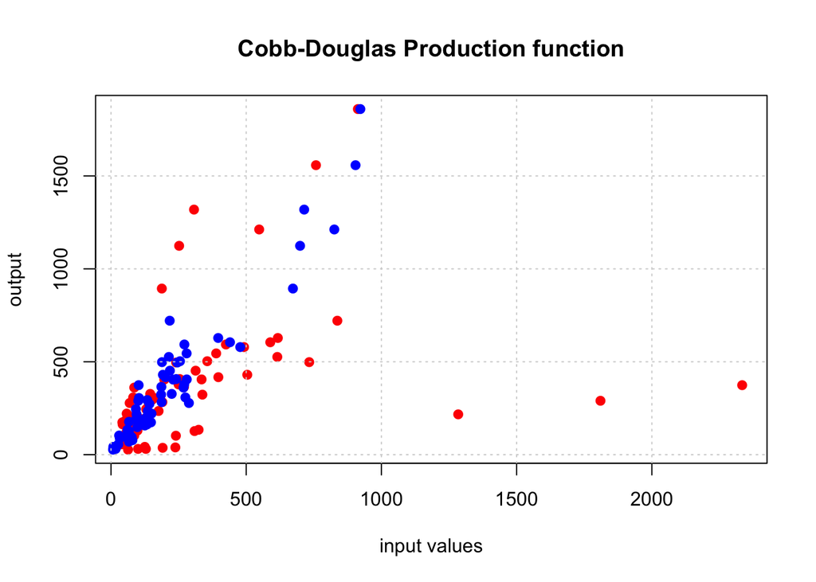

```r
plot(Cap, Q, pch=19, col='red', xlab= 'input values', ylab = 'output',
     main='Cobb-Douglas Production function')
points(Emp, Q, pch=19, col='blue')
grid()
```

A two-dimensional plot would be nice..

Set up a non-linear loss function

```r
CDloss=function(parms, Q, Cap, Emp){
  A = parms[1]
  alpha = parms[2]
  beta = parms[3]

  Loss = 0
  for (i in 1:length(Q)){
    Loss = Loss + ((Q[i]-A*(Cap[i]^beta*Emp[i]^alpha))^2)
  }

  return (log(Loss))
}

CDmle=function(parms, Q, Cap, Emp){
  A = parms[1]
  alpha = parms[2]
  beta = parms[3]

  logLoss = 0
  for (i in 1:length(Q)){
    errorTerm= (Q[i]-A*(Cap[i]^beta*Emp[i]^alpha))
    logLoss = logLoss - dnorm(errorTerm, log=T)
  }

  return (logLoss)
}
```

Test the loss function

```r
A = 1
alpha = 0.5
beta = 0.5
parms=c(A, alpha, beta)
print(CDloss(parms, Q, Cap, Emp))
```

```
## [1] 15.2447
```

```r
# better or worse than
A = 0.5
alpha = 0.5
beta = 0.5
parms=c(A, alpha, beta)
print(CDloss(parms, Q, Cap, Emp))
```

```
## [1] 16.06497
```

## Grid search

not the best idea, can get close to an answer

```r
for (A in seq(from=0.01, to = 2, length.out = 4))
  for(a in seq(from=0.01, to = 1,length.out = 6))
   for(b in seq(from=0.01, to = 1, length.out = 6)){
     parms = c(A, a, b)
      print(paste(A, a, b,'        ', CDloss(parms, Q, Cap, Emp)))
  }
```

```
## [1] "0.01 0.01 0.01          16.6856180686626"
## [1] "0.01 0.01 0.208          16.6855488317267"
## [1] "0.01 0.01 0.406          16.685320204032"
## [1] "0.01 0.01 0.604          16.6845453378081"
## [1] "0.01 0.01 0.802          16.6818553442254"
## [1] "0.01 0.01 1          16.6723232033395"
## [1] "0.01 0.208 0.01          16.6855504514634"
## [1] "0.01 0.208 0.208          16.685330749088"
## [1] "0.01 0.208 0.406          16.6845989171972"
## [1] "0.01 0.208 0.604          16.682103920724"
## [1] "0.01 0.208 0.802          16.673411871858"
## [1] "0.01 0.208 1          16.6425681340866"
## [1] "0.01 0.406 0.01          16.6853311982883"
## [1] "0.01 0.406 0.208          16.6846152266082"
## [1] "0.01 0.406 0.406          16.6822095339378"
```

[output cut: 129 more lines]

## non linear optimization

use function optim to find values of A, alpha, beta find values that minimize the loss function, loss = sum of sqrared errors. This is a ‘least squares’ solution

```r
##     ?optim
parms = c(2, 0.8, 0.2)
opt = optim(parms, CDloss, Q=Q, Cap=Cap, Emp=Emp)
print(opt)
```

```
## $par
## [1] 1.3044599 0.8287067 0.2215366
##
## $value
## [1] 12.97694
##
## $counts
## function gradient
##      170       NA
##
## $convergence
## [1] 0
##
## $message
## NULL
```

```r
parms = c(opt$par[1], opt$par[2], opt$par[3])
print(CDloss(parms, Q, Cap,Emp))
```

```
## [1] 12.97694
```

## maximum likelihood estimation

With the right fit, the residual errors should be independent, normally distributed, with mean 0. likelihood of the parameter set (a, $\alpha$, $\beta$) is

$\prod_0^n \phi(e_i)$

$\phi$ is the standard normal distribution

```r
parms = c(2, 0.8, 0.2)
opt = optim(parms, CDmle, Q=Q, Cap=Cap, Emp=Emp)
print(opt)
```

```
## $par
## [1] 1.3037106 0.8288269 0.2215117
##
## $value
## [1] 216230.4
##
## $counts
## function gradient
##      178       NA
##
## $convergence
## [1] 0
##
## $message
## NULL
```

```r
parms = c(opt$par[1], opt$par[2], opt$par[3])
print(CDmle(parms, Q, Cap,Emp))
```

```
## [1] 216230.4
```

```r
print(CDloss(parms,Q,Cap,Emp))
```

```
## [1] 12.97694
```

## transform to logs

```r
logModel = glm(log(Q)~log(Cap)+log(Emp))
summary(logModel)
```

```
##
## Call:
## glm(formula = log(Q) ~ log(Cap) + log(Emp))
##
## Deviance Residuals:
##      Min        1Q    Median        3Q       Max
## -0.44625  -0.14466   0.03981   0.12703   0.45446
##
## Coefficients:
##             Estimate Std. Error t value Pr(>|t|)
## (Intercept)  0.54032    0.15151   3.566 0.000663 ***
## log(Cap)     0.23234    0.02882   8.061 1.55e-11 ***
## log(Emp)     0.76531    0.02735  27.980  < 2e-16 ***
## ---
## Signif. codes:  0 '***' 0.001 '**' 0.01 '*' 0.05 '.' 0.1 ' ' 1
##
## (Dispersion parameter for gaussian family taken to be 0.04720648)
##
##     Null deviance: 64.5844  on 71  degrees of freedom
## Residual deviance:  3.2572  on 69  degrees of freedom
## AIC: -10.569
##
## Number of Fisher Scoring iterations: 2
```

```r
A = exp(logModel$coefficients[1])
alpha = logModel$coefficients[2]
beta = logModel$coefficients[3]
print(paste('A = ',A,' alpha = ', alpha,' beta =', beta))
```

```
## [1] "A =  1.71655367062008  alpha =  0.232343040964735  beta = 0.765310412619359"
```

```r
# CD loss at these values:
parms=c(A, alpha, beta)
print(paste('CD loss: ', CDloss(parms, Q, Cap, Emp)))
```

```
## [1] "CD loss:  15.7914789583455"
```

$$log(q) = 0.54 + 0.23 * log(k) * 0.77 * log(L)$$

$$Q = exp(0.54) * K^.23 * L^.77$$

$$A = Exp(.54), \alpha = 0.23, \beta = .77$$

## Questions:

## 1 what are the estimated values of A, alpha and beta?

$par [1] 1.3037106 0.8288269 0.2215117

$value [1] 216230.4

$counts function gradient 178 NA

$convergence [1] 0

$message NULL

[1] 12.97694

## 2 What are the confidence intervals on A, alpha, beta?

A = exp(0.54) = 1.72

Confidence interval for $\alpha$: 0.23 $\pm$ 1.96 * 0.03

Confidence interval for $\beta$: 0.77 $\pm$ 1.96 * 0.03

Confidence interval for A: log (A) $\pm$ 1.96 * 0.15 exp(log(A)) = A

Confidence interval for log(A) is 0.54 $\pm$ 1.96 * 0.15 = (0.25,0.82)

So the 95% confidence interval for A is exp(0.25), exp(0.82) = (1.28, 2.27)

[1] “A = 1.71655367062008 alpha = 0.232343040964735 beta = 0.765310412619359” [1] “CD loss: 15.7914789583455”

[output not shown]

A = exp(.54) exp(.15) UCL = exp(.54 + 1.96*.15) LCL = exp (.54 - 1.96*.15)

UCL CI alpha = 0.23 + 1.96 * 0.03 LCL CI alpha = 0.23 - 1.96 * 0.03